# Qualitative Personal Activity Recognition

PredMachLearn-030 Course Project

Han Dehai

Sunday, July 25, 2015

## Job description

Using wearable devices such as Jawbone Up, Nike FuelBand, and Fitbit it is now possible to collect a large amount of data about personal activity relatively inexpensively. One thing that people regularly do is quantify how much of a particular activity they do, but they rarely quantify how well they do it. In this project, we use data from accelerometers on the belt, forearm, arm, and dumbell of 6 participants. They were asked to perform barbell lifts correctly and incorrectly in 5 different ways. More information is available from the website here: http://groupware.les.inf.puc-rio.br/har(http://groupware.les.inf.puc-rio.br/har) (see the section on the Weight Lifting Exercise Dataset).

The goal of this project is to predict the manner in which they did the exercise. This is the “classe” variable in the training set.

## Modelling

For this problem, only the 53 variables that the testing data have are used for training and prediction.  
The training dataset is splited into 10 folds to train 10 models seperatly as my old laptop can’t handle the training work load using the whole dataset.  
Cross validations are then carried on these 10 folds.  
When using the random forest method, these 10 models actually have pretty good accuracies, i.e. between 94.14% and 95.46%.  
When using *random forest* on 20 folds, accuracies are between 89.89% and 92.22%.  
Methods of *naive bayes* (nb), *boosting with trees* (gbm) and *bagging* (bagFDA) were also tried on 10 folds, the accuracies were not as good as random forest.  
It is decided to choose one model from the 10 random forest models by means of manual voting. After voting the accuracy should be no less than the highest (95.46%) among the original 10 models, so the out of sample error should be around 4.54%.

```r
library(caret, quietly = TRUE)

training <- read.csv("pml-training.csv")
testing  <- read.csv("pml-testing.csv")

## First 7 variables are not from sensors, so they could not be used as predictors
training <- training[,-(1:7)]
testing  <- testing[,-(1:7)]

## NA testing
table(colSums(is.na(testing)))
```

```
##
##   0  20
##  53 100
```

```r
## 100 variables are totally missing, other 53 variables without NA

table(colSums(is.na(training)))
```

```
##
##     0 19216
##    86    67
```

```r
## 67 variables have 19216 (98%) missing values, other 86 variables without NA

## Use only 53 variables without NA
trainUsed <- training[,which(colSums(is.na(testing))==0)]
testUsed  <- testing[,which(colSums(is.na(testing))==0)]
```

```r
## My old laptop can't handle the training using the whole trainUsed dataset,
## so split it into 10 folds and train 10 models seperately
set.seed(2356)
trainList <- list(NULL)
n.folds <- 10
folds <- createFolds(trainUsed$classe, k = n.folds)
for(i in 1:n.folds){
  trainList[[i]] <- trainUsed[folds[[i]],]
}

modFitList <- list(NULL)

if(0){ ## don't want to run it every time compiling the Rmd file
  for(i in 1:n.folds){
    modFitList[[i]] <- train(classe ~ ., method = "rf", prox = TRUE,
                             data = trainList[[i]])
    filename <- paste("modFit_", i, ".rds", sep = "")
    saveRDS(modFitList[[i]], file = filename)
  }
  ## it costs about 22 minutes for each modFit, saving them for next time use
}

if(1){ ## just load the saved models
  for(i in 1:n.folds){
    filename <- paste("modFit_", i, ".rds", sep = "")
    modFitList[[i]] <- readRDS(file = filename)
  }
}
```

```r
## cross validation of models on folds except the fold of itself
cv.pred.acc <- as.numeric(NULL)
for(i in 1:n.folds){
  testData <- trainUsed[-folds[[i]],]
  cv.pred <- predict(modFitList[[i]], testData)
  cM <- confusionMatrix(cv.pred, testData$classe)
  cv.pred.acc <- c(cv.pred.acc, cM$overall[1])
}
range(cv.pred.acc)
```

```
## [1] 0.9413930 0.9545866
```

## Voting for the best model

Measure and score for each model using their prediction result on the testing data, which has the most agreed result wins.

```r
## Get the 10 predictions using each modFit in each row of df.pred
df.pred <- data.frame(NULL)
for(i in 1:n.folds){
  df.pred <- rbind(df.pred, predict(modFitList[[i]], testUsed))
}

## Name the 20 problems in each column of df.pred
name.pred <- as.character(NULL)
for(k in 1:20){
  name.pred <- c(name.pred, paste("pb", k, sep = ""))
}
names(df.pred) <- name.pred

## See what results each problem get
df.pred <- as.data.frame(sapply(df.pred, as.factor))
summary(df.pred)
```

```
##  pb1   pb2    pb3   pb4    pb5    pb6    pb7    pb8   pb9    pb10   pb11
##  2:9   1:10   1:3   1:10   1:10   5:10   4:10   2:5   1:10   1:10   1:1
##  3:1          2:6                               4:5                 2:7
##               3:1                                                   3:2
##  pb12   pb13   pb14   pb15   pb16   pb17   pb18  pb19  pb20
##  3:10   2:10   1:10   5:10   5:10   1:10   2:9   1:3   2:10
##                                            4:1   2:7
##
```

```r
## Which modFit has the most agreement when predicting the 20 problems
vt.pred <- as.data.frame(sapply(df.pred, as.integer))
for(i in 1:20){
  t.pred <- table(df.pred[,i])
  ord.names.pred <- names(t.pred[order(t.pred, decreasing = T)])
  for(j in 1:length(t.pred)){
    ## which modFit agrees with the 1st majority get a score of 5
    ## which modFit agrees with the 2nd majority get a score of 4
    ## etc
    vt.pred[df.pred[,i] == ord.names.pred[j], i] <- 6-j
  }
}
## Scores of the 10 modFits
vt.pred.mean <- apply(vt.pred, 1, mean)
no.best.modFit <- which.max(vt.pred.mean)
```

Here below shows the prediction results and model voting scores by fancy plots.

```r
## Codes below show the voting scores
library(reshape2)
modFit.id <- row.names(df.pred)
cp.df.pred <- cbind(modFit.id, df.pred)
mt.df.pred <- melt(cp.df.pred, id = "modFit.id")
```

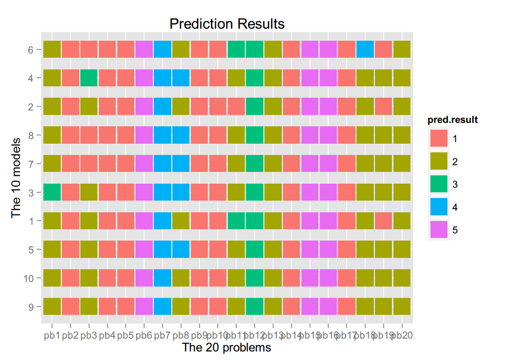

```r
names(mt.df.pred) <- c("modFit.id", "prob.id", "pred.result")

cp.vt.pred <- cbind(modFit.id, vt.pred)
mt.vt.pred <- melt(cp.vt.pred, id = "modFit.id")
names(mt.vt.pred) <- c("modFit.id", "prob.id", "pred.score")

m.pred <- merge(mt.df.pred, mt.vt.pred)
m.pred$modFit.id <- factor(m.pred$modFit.id,
                           levels = order(vt.pred.mean, decreasing = T))

library(ggplot2)
## plot prediction results
g_result <- ggplot(m.pred, aes(prob.id, modFit.id))
g_result <- g_result + geom_point(aes(color = pred.result), size = 8, shape = 15)
g_result + labs(list(title = "Prediction Results", x = "The 20 problems",
                     y = "The 10 models"))
```

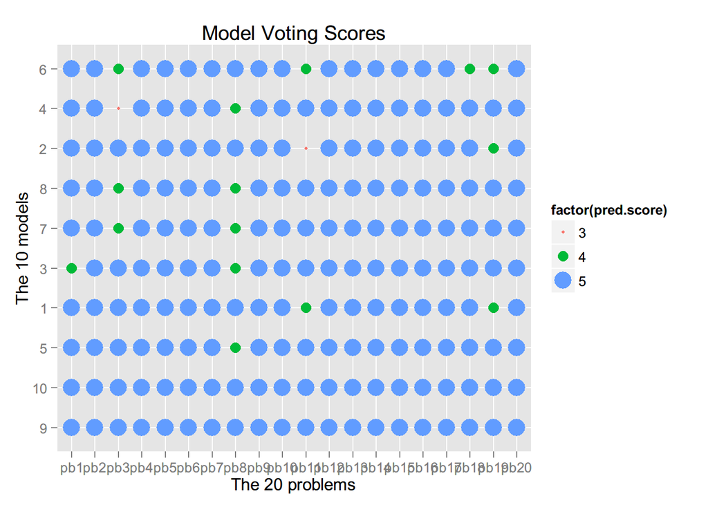

```r
## plot model voting scores
g_score <- ggplot(m.pred, aes(prob.id, modFit.id))
g_score <- g_score + geom_point(aes(color = factor(pred.score), size = factor(pred.score)))
g_score + labs(list(title = "Model Voting Scores", x = "The 20 problems",
                    y = "The 10 models"))
```

It shows that the 9th and 10th model have same result and both score all 5 points on every problem.  
That’s definitely what we are looking for.

## Prediction

```r
## prediction result of the best model
predict(modFitList[[no.best.modFit]], testUsed)
```

```
##  [1] B A B A A E D B A A B C B A E E A B B B
## Levels: A B C D E
```